# Упражнение № 7

Александрова Александра

16 04 2021

Необходимо построить две модели:

- зависимости непрерывного отклика от одного непрерывного предиктора;
- зависимости вероятности (логит) от одного непрерывного предиктора.

Для каждой модели:

1 Указать смысл переменных модели, метод оценки и настроечный параметр (степень полинома, гиперпараметр λ, ширина окна s, число узлов – в зависимости от метода).

2 Подогнать модель на всех наблюдениях, меняя значение настроечного параметра.

3 Обосновать оптимальное значение настроечного параметра подходящим методом (кросс-валидация, ANOVA).

4 Сделать прогноз на обучающую выборку по лучшей модели: модельные значения и ошибки прогноза.

5 Построить график с фактическими наблюдениями, модельной кривой и 95% доверительными интервалами прогноза.

В таблице ниже указаны набор данных, столбцы с переменными для модели и метод подгонки.

## Вариант № 2

Модели: Сглаживающий сплайн.

Данные: *Boston {MASS}*.

Работаем с набором данных по стоимости жилья в пригороде Бостона. Присоединяем его к пространству имён функцией attach(), и дальше обращаемся напрямую к столбцам таблицы.

```r
# загрузка данных Boston
data('Boston')

# ядро
my.seed <- 2
attach(Boston)
```

Работаем со столбцами:

- *indus* – доля нерозничных торговых площадей на город;
- *dis* – средневзвешенное расстояние до пяти бостонских центров занятости.

# Сглаживающий сплайн

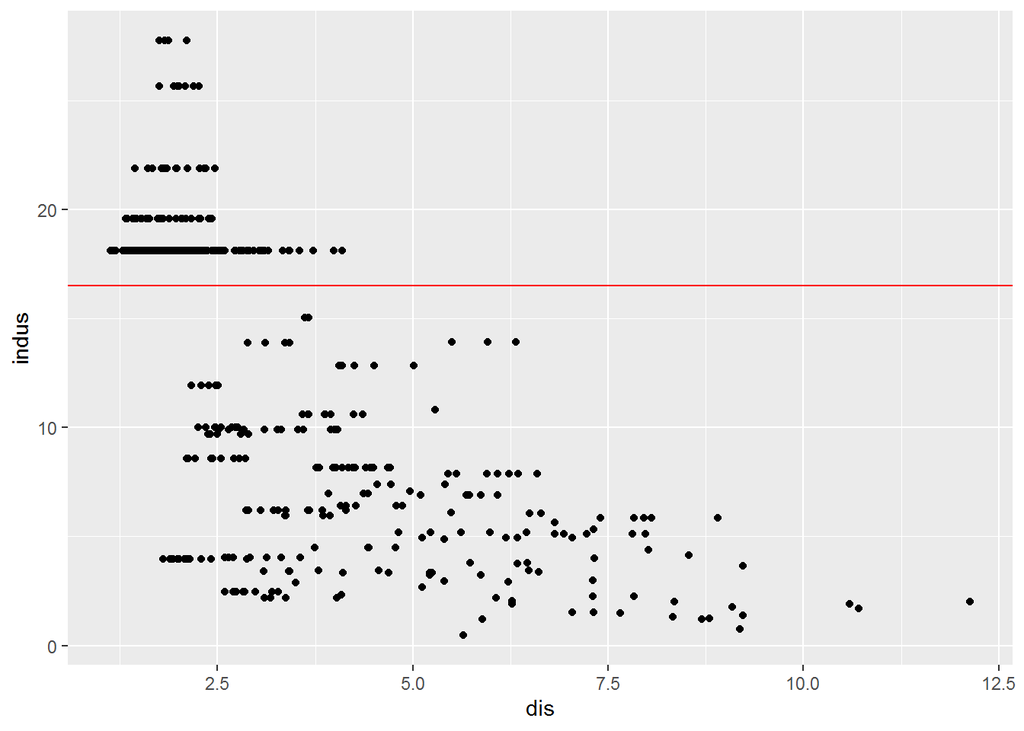

```r
gp <- ggplot(data = Boston, aes(x = dis, y = indus))
gp <- gp + geom_point() + geom_abline(slope = 0, intercept = 16.5, col = 'red')
gp
```